# TitanicSurvivors

Pravin Jeyaraj

1 July 2018

```r
train <- read.csv("e:/Data Science projects/Titanic/train.csv")
test <- read.csv("e:/Data Science projects/Titanic/test.csv")

names(train)
```

```
##  [1] "PassengerId" "Survived"    "Pclass"      "Name"        "Sex"
##  [6] "Age"         "SibSp"       "Parch"       "Ticket"      "Fare"
## [11] "Cabin"       "Embarked"
```

As the majority of fields are categorical, I have used logistic regression to build a model. I did not use PassengerId, Name, Ticket or Cabin, because they are unique identifiers.

```r
Survived.glm <- glm(Survived~Pclass+Sex+Age+SibSp+Parch+Fare+Embarked, data = train, family = "binomial")
summary(Survived.glm)
```

```
##
## Call:
## glm(formula = Survived ~ Pclass + Sex + Age + SibSp + Parch +
##     Fare + Embarked, family = "binomial", data = train)
##
## Deviance Residuals:
##     Min       1Q   Median       3Q      Max
## -2.7233  -0.6439  -0.3772   0.6288   2.4457
##
## Coefficients:
##               Estimate Std. Error z value Pr(>|z|)
## (Intercept)  17.894850 607.855475   0.029  0.97651
## Pclass       -1.199251   0.164619  -7.285 3.22e-13 ***
## Sexmale      -2.638476   0.222256 -11.871  < 2e-16 ***
## Age          -0.043350   0.008232  -5.266 1.39e-07 ***
## SibSp        -0.363208   0.129017  -2.815  0.00487 **
## Parch        -0.060270   0.123900  -0.486  0.62666
## Fare          0.001432   0.002531   0.566  0.57165
## EmbarkedC   -12.257443 607.855250  -0.020  0.98391
## EmbarkedQ   -13.080988 607.855453  -0.022  0.98283
## EmbarkedS   -12.658656 607.855228  -0.021  0.98339
## ---
## Signif. codes:  0 '***' 0.001 '**' 0.01 '*' 0.05 '.' 0.1 ' ' 1
##
## (Dispersion parameter for binomial family taken to be 1)
##
##     Null deviance: 964.52  on 713  degrees of freedom
## Residual deviance: 632.34  on 704  degrees of freedom
##   (177 observations deleted due to missingness)
## AIC: 652.34
##
## Number of Fisher Scoring iterations: 13
```

The liklihood of survival depends on class of ticket, gender, age and whether they were travelling with a spouse or siblings.

The liklihood of survival decreases if the passenger is male, older, had a lower class ticket and was travelling with a spouse or more siblings.

```r
test_predictions <- predict(Survived.glm, newdata = test, type="response")
Survived.pred = rep(0,418)
Survived.pred[test_predictions>.5]=1
PassengerID <- data.frame(test$PassengerId,Survived.pred)

table(PassengerID$Survived.pred == 1)
```

```
##
## FALSE  TRUE
##   287   131
```

```r
write.csv(PassengerID, file = "e:/Data Science projects/Titanic/submission_glm.csv")
```

Of the test dataset, 131 survived and 287 died.

The predictive accuracy can be improved using a regression tree.

```r
library(tree)

Survived.tree <- tree(Survived~Pclass+Sex+Age+SibSp+Parch+Fare+Embarked, data = train)
Survived.tree
```

```
## node), split, n, deviance, yval
##       * denotes terminal node
##
##  1) root 714 172.2000 0.4062
##    2) Sex: female 261  48.3100 0.7548
##      4) Pclass < 2.5 159   8.4910 0.9434 *
##      5) Pclass > 2.5 102  25.3400 0.4608
##       10) Fare < 20.8 79  19.4900 0.5570 *
##       11) Fare > 20.8 23   2.6090 0.1304 *
##    3) Sex: male 453  73.9100 0.2053
##      6) Age < 6.5 24   5.3330 0.6667
##       12) SibSp < 2.5 15   0.0000 1.0000 *
##       13) SibSp > 2.5 9   0.8889 0.1111 *
##      7) Age > 6.5 429  63.1800 0.1795
##       14) Pclass < 1.5 99  23.4100 0.3838
##         28) Age < 53 77  19.0900 0.4545 *
##         29) Age > 53 22   2.5910 0.1364 *
##       15) Pclass > 1.5 330  34.3900 0.1182 *
```

```r
summary(Survived.tree)
```

```
##
## Regression tree:
## tree(formula = Survived ~ Pclass + Sex + Age + SibSp + Parch +
##     Fare + Embarked, data = train)
## Variables actually used in tree construction:
## [1] "Sex"    "Pclass" "Fare"   "Age"    "SibSp"
## Number of terminal nodes:  8
## Residual mean deviance:  0.124 = 87.55 / 706
## Distribution of residuals:
##    Min. 1st Qu.  Median    Mean 3rd Qu.    Max.
## -0.9434 -0.1182 -0.1182  0.0000  0.0566  0.8889
```

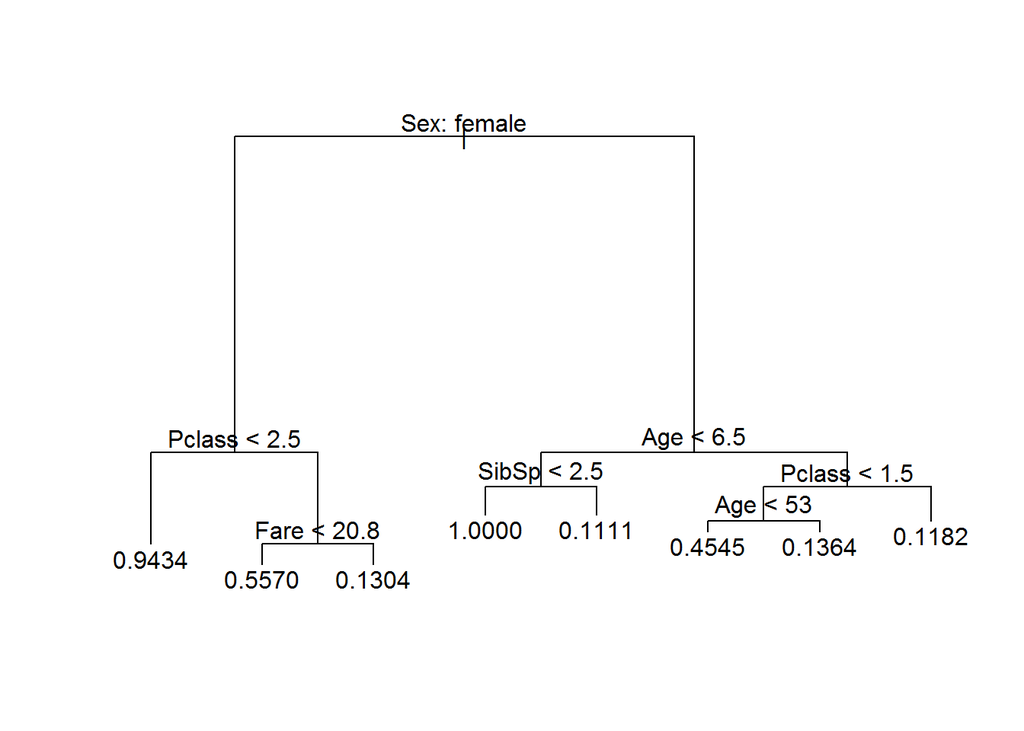

```r
plot(Survived.tree)
text(Survived.tree, pretty = 0)
```

If the passenger was male, he was most likely to survive if he was younger than 6.5 years and was travelling with one or two siblings or a spouse. He was unlikely to survive if he was travelling with three or more siblings or a spouse. He was not likely to survive ha he was older than 6.5 years but the risk of death was less if he had first class ticket and was younger than 53 years.

```r
test_predictions <- predict(Survived.tree, newdata = test)

Survived.pred = rep(0,418)
Survived.pred[test_predictions>.5]=1

PassengerID <- data.frame(test$PassengerId,Survived.pred)

table(PassengerID$Survived.pred == 1)
```

```
##
## FALSE  TRUE
##   268   150
```

```r
write.csv(PassengerID, file = "e:/Data Science projects/Titanic/submission_regtree.csv")
```

Of the test dataset, 150 survived and 268 died.

Since only five out of seven variables were used in the construction of the tree, increasing the number of variables in the formula will not make any difference.

# How much can the tree be pruned for better interpretation without affecting the accuracy?

```r
survived.tree.cv <- cv.tree(Survived.tree)
summary(survived.tree.cv)
```

```
##        Length Class  Mode
## size   8      -none- numeric
## dev    8      -none- numeric
## k      8      -none- numeric
## method 1      -none- character
```

```r
survived.tree.cv
```

```
## $size
## [1] 8 7 6 5 4 3 2 1
##
## $dev
## [1]  97.45567  97.36322  97.89091 102.56259 109.62895 109.62895 122.95722
## [8] 172.96980
##
## $k
## [1]      -Inf  1.732323  3.240771  4.444444  5.374437  5.394464 14.472810
## [8] 49.999087
##
## $method
## [1] "deviance"
##
## attr(,"class")
## [1] "prune"         "tree.sequence"
```

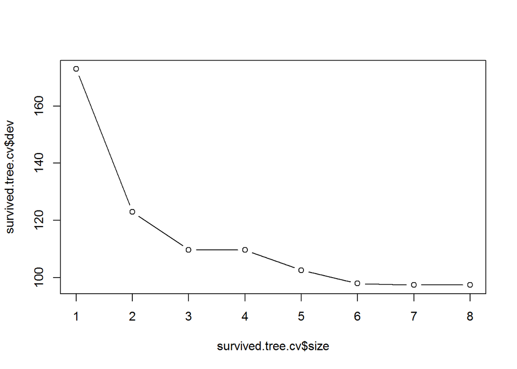

```r
plot(survived.tree.cv$size,survived.tree.cv$dev,type='b')
```

The tree can be pruned to seven levels without affecting the accuracy. With more levels, there is a risk that the model will be overfit to the data. With less levels, the model may be less accurate.

```r
survived.tree.prune <- prune.tree(Survived.tree,best=7)

test_predictions <- predict(survived.tree.prune, newdata = test)

Survived.pred = rep(0,418)
Survived.pred[test_predictions>.5]=1

PassengerID <- data.frame(test$PassengerId,Survived.pred)

table(PassengerID$Survived.pred == 1)
```

```
##
## FALSE  TRUE
##   268   150
```

```r
write.csv(PassengerID, file = "e:/Data Science projects/Titanic/submission_regtreeprune.csv")
```

# Can I improve the accuracy by omitting blank elements?

```r
table(is.na(train$Fare))
```

```
##
## FALSE
##   891
```

```r
table(is.na(train$Sex))
```

```
##
## FALSE
##   891
```

```r
table(is.na(train$SibSp))
```

```
##
## FALSE
##   891
```

```r
table(is.na(train$Parch))
```

```
##
## FALSE
##   891
```

```r
table(is.na(train$Embarked))
```

```
##
## FALSE
##   891
```

```r
table(is.na(train$Pclass))
```

```
##
## FALSE
##   891
```

```r
table(is.na(train$Age))
```

```
##
## FALSE  TRUE
##   714   177
```

There only field included in model with missing data is Age. in 177 observations in the training data, the age is missing.

```r
train2 <- na.omit(train)

nrow(train2)
```

```
## [1] 714
```

```r
median(train2$Age)
```

```
## [1] 28
```

```r
mean(train2$Age)
```

```
## [1] 29.69912
```

Without the observations with missing observations, there are 714 observations

```r
Survived.tree <- tree(Survived~Fare+Sex+Age+SibSp+Parch+Embarked+Pclass, data = train2)
Survived.tree
```

```
## node), split, n, deviance, yval
##       * denotes terminal node
##
##  1) root 714 172.2000 0.4062
##    2) Sex: female 261  48.3100 0.7548
##      4) Pclass < 2.5 159   8.4910 0.9434 *
##      5) Pclass > 2.5 102  25.3400 0.4608
##       10) Fare < 20.8 79  19.4900 0.5570 *
##       11) Fare > 20.8 23   2.6090 0.1304 *
##    3) Sex: male 453  73.9100 0.2053
##      6) Age < 6.5 24   5.3330 0.6667
##       12) SibSp < 2.5 15   0.0000 1.0000 *
##       13) SibSp > 2.5 9   0.8889 0.1111 *
##      7) Age > 6.5 429  63.1800 0.1795
##       14) Pclass < 1.5 99  23.4100 0.3838
##         28) Age < 53 77  19.0900 0.4545 *
##         29) Age > 53 22   2.5910 0.1364 *
##       15) Pclass > 1.5 330  34.3900 0.1182 *
```

```r
summary(Survived.tree)
```

```
##
## Regression tree:
## tree(formula = Survived ~ Fare + Sex + Age + SibSp + Parch +
##     Embarked + Pclass, data = train2)
## Variables actually used in tree construction:
## [1] "Sex"    "Pclass" "Fare"   "Age"    "SibSp"
## Number of terminal nodes:  8
## Residual mean deviance:  0.124 = 87.55 / 706
## Distribution of residuals:
##    Min. 1st Qu.  Median    Mean 3rd Qu.    Max.
## -0.9434 -0.1182 -0.1182  0.0000  0.0566  0.8889
```

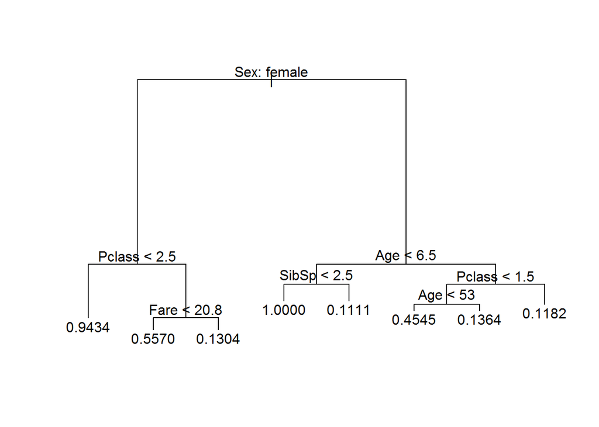

```r
plot(Survived.tree)
text(Survived.tree, pretty = 0)
```

```r
survived.tree.cv <- cv.tree(Survived.tree)
summary(survived.tree.cv)
```

```
##        Length Class  Mode
## size   8      -none- numeric
## dev    8      -none- numeric
## k      8      -none- numeric
## method 1      -none- character
```

```r
survived.tree.cv
```

```
## $size
## [1] 8 7 6 5 4 3 2 1
##
## $dev
## [1]  98.52207  98.33018  97.20928 104.15735 109.91594 109.91594 123.08564
## [8] 172.70156
##
## $k
## [1]      -Inf  1.732323  3.240771  4.444444  5.374437  5.394464 14.472810
## [8] 49.999087
##
## $method
## [1] "deviance"
##
## attr(,"class")
## [1] "prune"         "tree.sequence"
```

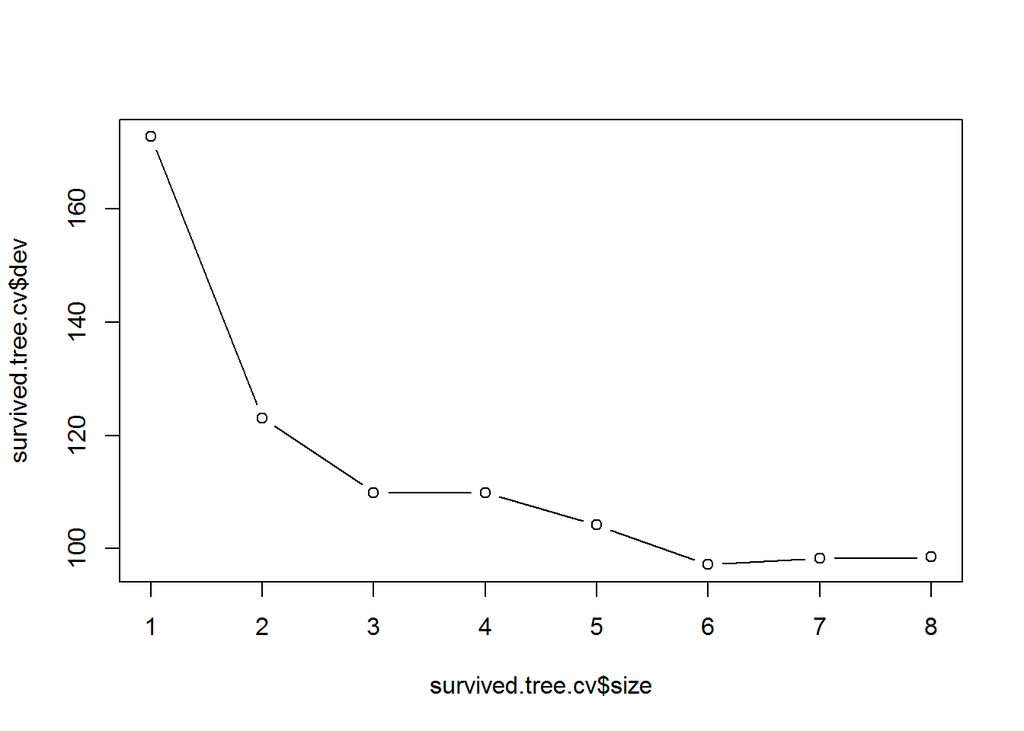

```r
plot(survived.tree.cv$size,survived.tree.cv$dev,type='b')
```

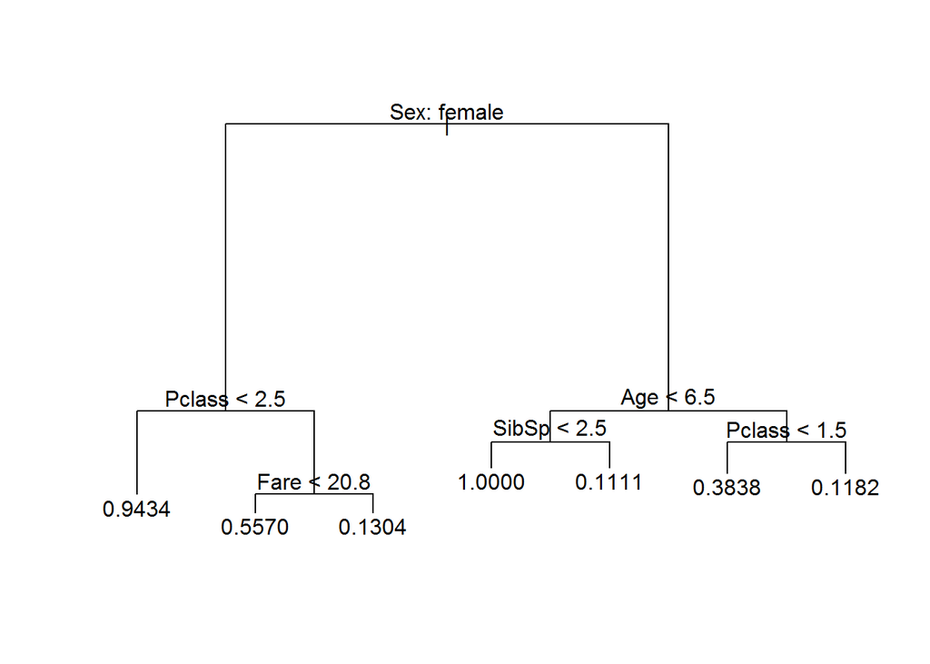

```r
survived.tree.prune <- prune.tree(Survived.tree,best=7)
plot(survived.tree.prune)
text(survived.tree.prune, pretty = 0)
```

```r
test_predictions <- predict(survived.tree.prune, newdata = test)

Survived.pred = rep(0,418)
Survived.pred[test_predictions>.5]=1

PassengerID <- data.frame(test$PassengerId,Survived.pred)

write.csv(PassengerID, file = "e:/Data Science projects/Titanic/submission_regtreeomit.csv")

table(PassengerID$Survived.pred == 1)
```

```
##
## FALSE  TRUE
##   268   150
```

Omitting the training data with missing ages does not affect the predictions on the test data.